CA3 Reza Abdoli 810100251

# Goal

In this notebook we are going to learn clustring containing diffrent techniques like K-means and DBSCAN, label different images and extracting images feature using VGG16.

### to extract features of images we will need some libraries such as keras that I have imported them:

```python
#%pip install tensorflow
```

```python
#%pip install keras
```

```python
#%conda install keras
```

```python
from __future__ import print_function

import numpy as np
import warnings
from tensorflow.keras.preprocessing import image
from tensorflow.keras.applications.vgg16 import preprocess_input
from keras import utils
from keras.models import Model
from keras.layers import Flatten
from keras.layers import Dense
from keras.layers import Input
from keras.layers import Conv2D
from keras.layers import MaxPooling2D
from keras.layers import GlobalMaxPooling2D
from keras.layers import GlobalAveragePooling2D
from keras.preprocessing import image
from keras import backend as K
from keras.applications.imagenet_utils import decode_predictions
from keras.applications.imagenet_utils import preprocess_input
from keras.applications.vgg16 import VGG16
from sklearn.cluster import KMeans
```

## Preprocessing and feature extraction

[figure not shown]

### In this section, we extract the features of each photo according to the vgg16 model (the pictures above).

```python
def VGGupdated(input_tensor=None,classes=10):

    img_rows, img_cols = 224, 224
    img_channels = 3

    img_dim = (img_rows, img_cols, img_channels)

    img_input = Input(shape=img_dim)

    # Block 1
    x = Conv2D(64, (3, 3), activation='relu', padding='same', name='block1_conv1')(img_input)
    x = Conv2D(64, (3, 3), activation='relu', padding='same', name='block1_conv2')(x)
    x = MaxPooling2D((2, 2), strides=(2, 2), name='block1_pool')(x)

    # Block 2
    x = Conv2D(128, (3, 3), activation='relu', padding='same', name='block2_conv1')(x)
    x = Conv2D(128, (3, 3), activation='relu', padding='same', name='block2_conv2')(x)
    x = MaxPooling2D((2, 2), strides=(2, 2), name='block2_pool')(x)

    # Block 3
    x = Conv2D(256, (3, 3), activation='relu', padding='same', name='block3_conv1')(x)
    x = Conv2D(256, (3, 3), activation='relu', padding='same', name='block3_conv2')(x)
    x = Conv2D(256, (3, 3), activation='relu', padding='same', name='block3_conv3')(x)
    x = MaxPooling2D((2, 2), strides=(2, 2), name='block3_pool')(x)

    # Block 4
    x = Conv2D(512, (3, 3), activation='relu', padding='same', name='block4_conv1')(x)
    x = Conv2D(512, (3, 3), activation='relu', padding='same', name='block4_conv2')(x)
    x = Conv2D(512, (3, 3), activation='relu', padding='same', name='block4_conv3')(x)
    x = MaxPooling2D((2, 2), strides=(2, 2), name='block4_pool')(x)

    # Block 5
    x = Conv2D(512, (3, 3), activation='relu', padding='same', name='block5_conv1')(x)
    x = Conv2D(512, (3, 3), activation='relu', padding='same', name='block5_conv2')(x)
    x = Conv2D(512, (3, 3), activation='relu', padding='same', name='block5_conv3')(x)
    x = MaxPooling2D((2, 2), strides=(2, 2), name='block5_pool')(x)


    model = Model(inputs = img_input, outputs = x, name='VGGdemo')


    return model
```

### Q1

- Extracting features from images using models like VGG16 serves several purposes:
  - Conversion of image information into feature space: Images contain a wealth of information that isn't readily understandable by simply looking at pixels.
  - Transfer learning: Features extracted from pre-trained models like VGG16 can be used as input for new models trained for specific tasks such as object detection in images
  - Deeper semantic understanding: By using features extracted from deep neural network models, we can obtain meaningful and valuable insights from images.

### Q2

- 1. Convolutional Neural Networks (CNNs): CNNs are powerful tools for extracting features from images. These networks automatically extract features ranging from low-level features like edges and corners to high-level features like objects and meaningful patterns from images.
  2. Wavelet Transform-based Methods: These methods use wavelet analysis to decompose images into components of different frequencies.
  3. Geometric and Statistical Features-based Methods: These methods extract geometric features such as shape, size, and object positions from images.

### Q3

- Preprocessing of images before feeding them into a model typically involves the following steps:
  - Resizing: Images usually come in different sizes, and for optimal use with models, they need to be resized to a specific, often square, size.
  - Normalization: This step involves scaling the pixel values to a specific range, such as [0, 1] or [-1, 1]. Normalization ensures that input values to the model fall within appropriate ranges and addresses issues like saturation or inconsistency in pixel values.
  - Conversion to Model's Input Format: Some models may require images to be in specific input formats, such as CNN models often expecting RGB images with certain dimensions. Therefore, images need to be converted to this format.

## Reading and storing images

```python
import os
def read_and_preprocess_images(directory_path):
    images = []
    for i in range(1, 211):
        filename = '{:04d}.png'.format(i)
        image_path = os.path.join(directory_path, filename)
        if os.path.exists(image_path):
            img = image.load_img(image_path, target_size=(224, 224))
            img_array = image.img_to_array(img)
            img_array = np.expand_dims(img_array, axis=0)
            img_array = preprocess_input(img_array)
            images.append(img_array)
        else:
            print(f"Image file {filename} not found.")

    return np.vstack(images)

# Read and preprocess images
directory_path = "flower_images"
images_array = read_and_preprocess_images(directory_path)
len(images_array)

model = VGGupdated(classes = 10)
features = model.predict(images_array)
features
```

[output not shown]

[output not shown]

[output cut: 468 more lines]

[output not shown]

```python
features.shape
```

```
(210, 7, 7, 512)
```

## implementing clustering and Dimension reduction

### Q4

- K-Means and DBSCAN are two clustering algorithms used to group data points based on their similarities. Each has its own strengths and weaknesses, and the best choice depends on your specific needs and data characteristics.

## k-means:

### Advantages:

- - - Efficiency with Large Datasets: Effective clustering is often needed for large and complex datasets, and Means-K is suitable for this purpose.

Ability to Specify Cluster Number: This method allows the user to specify the desired number of clusters

### Disadvantages:

- - Susceptibility to Outliers: Outliers can influence the cluster centers, affecting the clustering results

## dbscan:

### Advantages:

- - - Good Performance with Dense Data: DBSCAN works well when data points are densely clustered.

### Disadvantages:

  - - Parameter Tuning Required: Some parameters of DBSCAN such as epsilon and minPts need to be tuned, which can be a drawback.

### Q5

- I chose the best value of k by guessing and experimenting and testing for different values of k and comparing the correctness of the labels

### Q6

- The resulting output using the k-means algorithm gives a relatively correct output in some cases, Unfortunately, despite a lot of searching and limited time, I did not understand the reason for the dbscan algorithm not working and the bug

## Running k-means

```python
n_samples, height, width, channels = features.shape
features_reshaped = features.reshape(n_samples, height * width * channels)

n_clusters = 10

kmeans = KMeans(n_clusters=n_clusters,n_init=10)
kmeans.fit(features_reshaped)
cluster_labels = kmeans.labels_
```

Finally, the clustering labels for each image are returned as cluster_labels, where each label corresponds to one of the n_clusters clusters that each image belongs to.

```python
cluster_labels
```

```
array([9, 4, 4, 7, 1, 1, 5, 6, 4, 9, 4, 3, 1, 7, 9, 7, 8, 5, 4, 4, 4, 2,
       7, 9, 9, 8, 9, 4, 0, 8, 6, 0, 5, 5, 5, 9, 5, 7, 9, 9, 7, 5, 6, 4,
       4, 5, 5, 6, 6, 9, 6, 5, 3, 8, 6, 0, 7, 5, 9, 1, 1, 1, 6, 5, 4, 5,
       3, 4, 0, 2, 7, 3, 8, 6, 9, 6, 8, 5, 9, 3, 7, 2, 9, 7, 5, 1, 9, 5,
       0, 5, 7, 8, 4, 9, 1, 9, 9, 7, 9, 8, 8, 5, 5, 7, 7, 9, 9, 9, 1, 4,
       4, 5, 1, 8, 3, 4, 9, 8, 1, 5, 8, 3, 5, 5, 3, 6, 9, 0, 9, 8, 6, 9,
       7, 2, 5, 9, 4, 0, 3, 2, 1, 9, 6, 3, 4, 7, 5, 5, 3, 1, 3, 5, 3, 9,
       3, 8, 1, 9, 8, 7, 5, 7, 3, 5, 9, 7, 7, 8, 8, 6, 8, 7, 1, 3, 9, 5,
       7, 9, 6, 9, 0, 5, 9, 3, 0, 3, 0, 6, 6, 5, 5, 3, 1, 8, 4, 5, 0, 4,
       0, 2, 1, 6, 9, 7, 5, 3, 9, 2, 8, 3])
```

## Dimension reduction (pca)

### Q7

- pca is a dimensionality reduction method commonly used for data analysis, particularly for reducing the dimensions of feature space. It helps us effectively decompose dense and redundant information present in high-dimensional data into a more manageable and meaningful form.

in the code below we are going to create a scatter plot to visualize the clusters in the reduced dimensional space. It loops through each cluster and plots the points corresponding to that cluster label. It uses boolean indexing to select points belonging to each cluster label. Finally, it adds labels, title, and legend to the plot, then displays it.

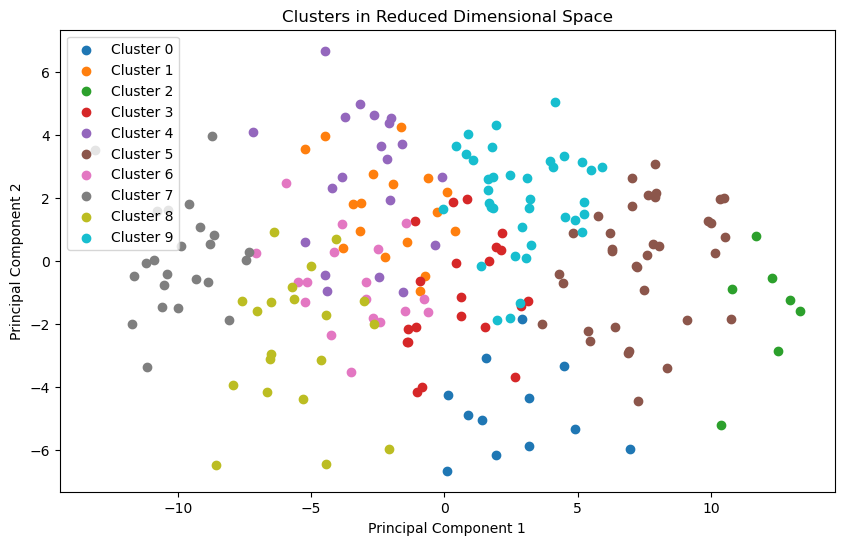

```python
from sklearn.decomposition import PCA
import matplotlib.pyplot as plt


# Apply PCA for dimensionality reduction
pca = PCA(n_components=2)  # Reduce to 2 dimensions for visualization
features_pca = pca.fit_transform(features_reshaped)

# Plot clusters in the reduced space
plt.figure(figsize=(10, 6))
for cluster_label in range(n_clusters):
    plt.scatter(features_pca[cluster_labels == cluster_label, 0],
                features_pca[cluster_labels == cluster_label, 1],
                label=f'Cluster {cluster_label}')
plt.title('Clusters in Reduced Dimensional Space')
plt.xlabel('Principal Component 1')
plt.ylabel('Principal Component 2')
plt.legend()
plt.show()
```